# Лабораторная работа №7

Анализ файловой системы Linux. Команды для работы с файлами и каталогами

Прозорова Е. Е.

Российский университет дружбы народов, Москва, Россия

20 марта 2025

# Информация

## Докладчик

- Прозорова Елизавета Евгеньевна
- студент факультета ФМиЕН
- группа НММбд-03-24
- Российский университет дружбы народов
- 1132246767@pfur.ru

# Вводная часть

## Цели и задачи

- Ознакомление с файловой системой Linux, её структурой, именами и содержанием каталогов.
- Приобретение практических навыков по применению команд для работы с файлами и каталогами, по управлению процессами (и работами), по проверке использования диска и обслуживанию файловой системы

# Выполнение лабораторной работы

## 1 и 2

Я осуществите вход в систему, используя соответствующее имя пользователя.

Я записала в файл file.txt названия файлов, содержащихся в каталоге /etc. Затем я дописала в этот же файл названия файлов, содержащихся в домашнем каталоге.

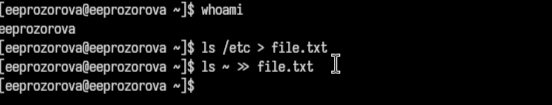

Запись в файл file.txt названия файлов, содержащихся в каталоге /etc и домашнем каталоге

## 3

Я вывела имена всех файлов из file.txt, имеющих расширение .conf, после чего записала их в новый текстовой файл conf.txt

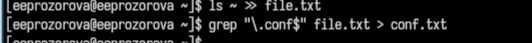

Вывод имена всех файлов из file.txt и запись из в файл conf.txt

## 4

Я определила, какие файлы в домашнем каталоге имеют имена, начинавшиеся с символа c двумя способами.

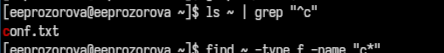

Первый способ

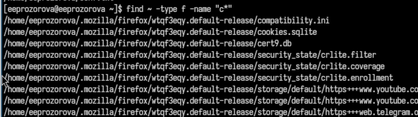

Второй способ

## 5

Я вывела на экран (по странично) имена файлов из каталога /etc, начинающиеся с символа h.

[figure not shown]

## 6 и 7

Я запустила в фоновом режиме процесс, который будет записывать в файл ~/logfile файлы, имена которых начинаются с log. Затем удалила файл ~/logfile.

## 8

Я запустила из консоли в фоновом режиме редактор gedit.

## 9

Я определила идентификатор процесса gedit, используя команду ps, конвейер и фильтр grep.

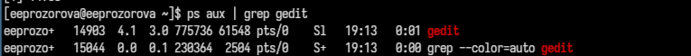

Фильтр grep

Я также попробовала для этого задания команду pgrep

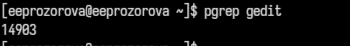

Команда pgrep

## 10

Я прочла справку (man) команды kill, после чего использовала её для завершения процесса gedit

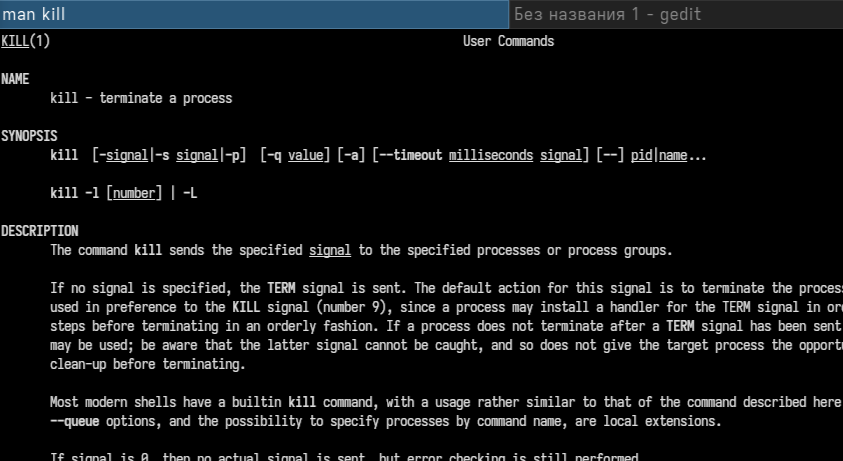

Справка kill

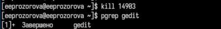

## 11

Я выполнила команды df и du, предварительно получив более подробную информацию об этих командах, с помощью команды man.

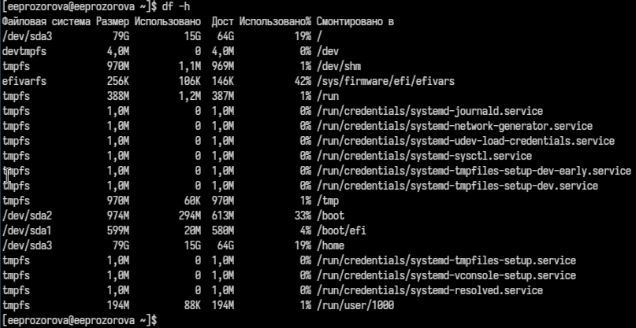

Команда df

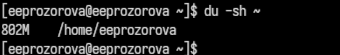

Команда du

## 12

Воспользовавшись справкой команды find, вывела имена всех директорий, имеющихся в домашнем каталоге.

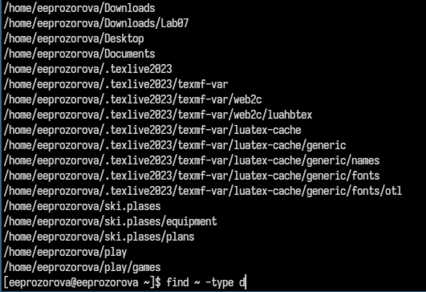

Все директории

# Выводы

Я ознакомилась инструментами поиска файлов и фильтрации текстовых данных. Я приобрела практические навыки по управлению процессами (и заданиями), по проверке использования диска и обслуживанию файловых систем.